# Statistical Computing Homework 2, Chapter 1

Ziqi Yang

14 September, 2018

# 1 Exercise 2: Monte Carlo methods

## 1.1 R Code

```r
N <- c(100 ,1000, 10000);  Ts <- c(0.0, 0.67, 0.84, 1.28, 1.65, 2.32, 2.58, 3.09, 3.72)
experiment <- array( 0, dim = c(length(N), length(Ts), 100) )

for (expe in 1:100) {
  for (t in 1:length(Ts)) {
    for (n in 1:length(N)) {
      temp <- rnorm(N[n], mean = 0, sd = 1)
      experiment[n ,t , expe] <- sum( ifelse( temp <= Ts[t], 1, 0 ) ) / N[n]
    }
  }
}
```

## 1.2 Table for the result:

```r
library(knitr)
knitr::kable(data.frame(rbind(experiment[,,1], pnorm(Ts))), format = "markdown",
             row.names = T, col.names = Ts)
```

|  | 0 | 0.67 | 0.84 | 1.28 | 1.65 | 2.32 | 2.58 | 3.09 | 3.72 |
| --- | --- | --- | --- | --- | --- | --- | --- | --- | --- |
| 1 | 0.4500 | 0.7700000 | 0.8400000 | 0.9100000 | 0.9500000 | 0.9900000 | 0.98000 | 1.0000000 | 1.0000000 |
| 2 | 0.5080 | 0.7450000 | 0.8030000 | 0.9110000 | 0.9470000 | 0.9890000 | 0.99200 | 1.0000000 | 1.0000000 |
| 3 | 0.5033 | 0.7468000 | 0.7981000 | 0.8983000 | 0.9526000 | 0.9903000 | 0.99480 | 0.9994000 | 0.9999000 |
| 4 | 0.5000 | 0.7485711 | 0.7995458 | 0.8997274 | 0.9505285 | 0.9898296 | 0.99506 | 0.9989992 | 0.9999004 |

Row 1 is for **$n = 10^2$**, row 2 is for **$n = 10^3$**, row 3 is for **$n = 10^4$**, row 4 is for actual probability. We can see that when n becomes greater and greater, the simulated probability is approximately the actual probability.

## 1.3 Boxplots:

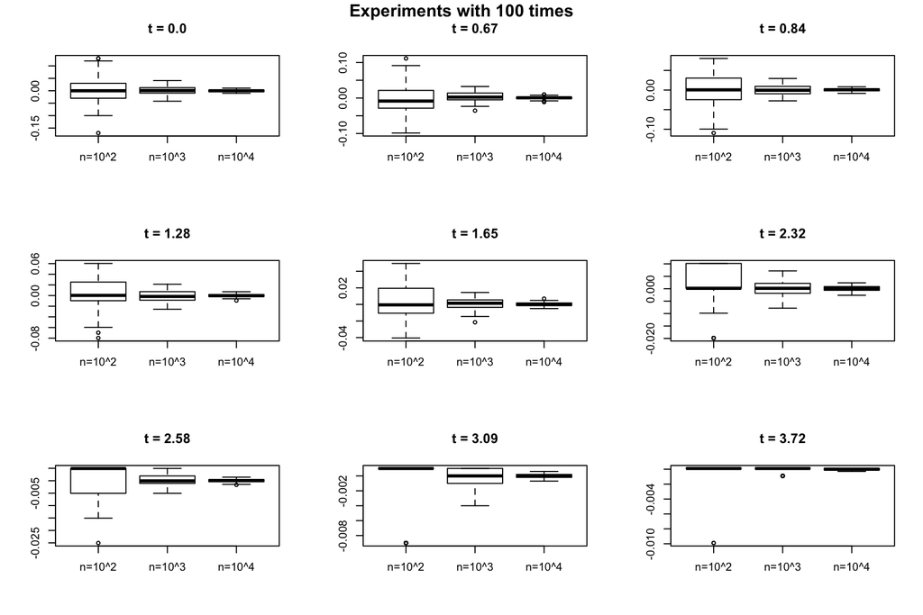

# 2 Exercise 3

## 2.1 .Machine$double.xmax: 1.797693e+308

- Since we are using the 64-bit double precision floating point arithmetic, so we have 1 bit of sign, 11 bits of exponent, 52 bits of significand
- First, for sign bit, this bit should take value 0, so $(-1)^0 = 1$, since we want to get the largest number
- Second, for exponent bits, if we fill all 11 bits with 1, then we have $2^0+2^1+2^2+...+2^10=2^11-1=2047$, but $2047$ is reserved for infinity, and also it’s normalized by subtracing $1023$, so we have $2046-1023=1023$
- We fill the significand with all 1, then we $2^{-1}+2^{-2}+...+2^{-52}=1-2^{-52}$, but remember to add 1 before the radix point, we have $1+1-2^{-52}=2-2^{-52}$
- So if we compute $(2-2^{-52}) \times 2^{1023}$, then we should have $1.797693e+308$, which is .Machine$double.max

## 2.3 .Machine$double.eps: 2.220446e-16

- This is machine $\epsilon$
- so if we set the last digit in significand to be 1, and remain 0, then we have $1+2^{-52} \neq 1$, so $2^{-52}$ is machine $\epsilon$ , it’s equal to $2.220446e-16$

## 2.4 .Machine$double.neg.eps: 1.110223e-16

- Since $1 - \epsilon = 1.1111...1110 \times 2^{-1}$, so there is one number between this and $1$, which is $1.1111...1111 \times 2^{-1} = 1 - \epsilon/2 \neq 1$, so .Machine$double.neg.eps is $\epsilon/2=2^{-53}=1.110223e-16$